# Cleaning data from SSB API

Andreas Olden and Erling Risa

January 23, 2019

# Loading the data

```r
df_10594 <- readRDS(here("data/raw", "df_10594.rds"))
df_07459 <- readRDS(here("data/raw", "df_07459.rds"))
df_06726 <- readRDS(here("data/raw", "df_06726.rds"))
df_europe_brent_spot <- readRDS(here("data/raw", "df_europe_brent_spot.rds"))
```

# Looking, diagnozing and cleaning data

### 10594 unemployment

Let us start out by taking a look at the data frame, missing values and the regions

```r
skim(df_10594) #Show nice summary stats
```

```
Skim summary statistics
 n obs: 3648
 n variables: 5

-- Variable type:factor --------------------------------------------------------
 variable missing complete    n n_unique                             top_counts ordered
 contents       0     3648 3648        1                       Une: 3648, NA: 0   FALSE
    month       0     3648 3648      304     199: 12, 199: 12, 199: 12, 199: 12   FALSE
   region       0     3648 3648        4 Osl: 912, Sta: 912, Ber: 912, Tro: 912   FALSE
      sex       0     3648 3648        3 Bot: 1216, Mal: 1216, Fem: 1216, NA: 0   FALSE

-- Variable type:integer -------------------------------------------------------
 variable missing complete    n    mean      sd  p0  p25  p50  p75  p100     hist
    value       3     3645 3648 3427.85 3000.92 290 1366 2390 4440 16106 ▇▅▂▁▁▁▁▁
```

```r
df_10594[is.na(df_10594$value),] #To locate and show the missing values
```

|  | region | sex | contents | month | value |
| --- | --- | --- | --- | --- | --- |
| 3040 | Trondheim (-2017) | Both sexes | Unemployed persons registered at the Employment Offices | 2018M11 | NA |
| 3344 | Trondheim (-2017) | Males | Unemployed persons registered at the Employment Offices | 2018M11 | NA |
| 3648 | Trondheim (-2017) | Females | Unemployed persons registered at the Employment Offices | 2018M11 | NA |

```r
unique(df_10594$region) #To show all the regions
```

```
[1] Oslo municipality Stavanger         Bergen            Trondheim (-2017)
Levels: Oslo municipality Stavanger Bergen Trondheim (-2017)
```

Allright. The data consists of five variables: region, sex, contents, month and value, all are unordered factors, except for value, which is integer. There are aslo 4 regions, Oslo muni, Stavanger, Bergen and Trondheim (-2017). There are also three missing values, all from Trondheim in 2018, despite the fact that the data states -2017. This is due to the previous issue of Trondheim being classified as 1601 and 5001 and presumably a mistake by SSB. By looking at the relevant table in the Statbank https://www.ssb.no/statbank/table/10594 we could replace them or merge the variables. However, since the housing price data only runs from 1992-2017 we will only use this time period and not have to deal with it.

We want to clean the data a bit as well. The contents variable is simply a description of the value variable and we want to rename the value-variable to reg_unemployed and drop the contents variable, as well as make it numeric rather than integer. Further we want to rename ‘month’ as date and recode it as a date format. Then, we will change the factor levels so that Oslo municipality is only called Oslo, and Trondheim (-2017) is only called Trondheim. Finally, we will filter the time periods so that we only have observations from 1992-2017. Several of these steps will be used for several of the datasets.

```r
df_10594 <- df_10594 %>%
        mutate( date = lubridate::parse_date_time(month, "ym"),
                region = fct_recode(region,
                                    Oslo = "Oslo municipality",
                                    Trondheim = "Trondheim (-2017)"),
                value = as.numeric(value)) %>%
        rename( reg_unemployed = value) %>%
        select(-c(month, contents)) %>%
        filter(date >= as.Date("1992-01-01") & date < as.Date("2018-01-01"))
saveRDS(df_10594, file = here("data/processed", "df_unemployment.rds"))
```

And let us take a new look at the data

```r
skim(df_10594)
```

```
Skim summary statistics
 n obs: 3348
 n variables: 4

-- Variable type:factor --------------------------------------------------------
 variable missing complete    n n_unique                             top_counts ordered
   region       0     3348 3348        4 Osl: 837, Sta: 837, Ber: 837, Tro: 837   FALSE
      sex       0     3348 3348        3 Bot: 1116, Mal: 1116, Fem: 1116, NA: 0   FALSE

-- Variable type:numeric -------------------------------------------------------
       variable missing complete    n    mean      sd  p0    p25    p50    p75  p100     hist
 reg_unemployed       0     3348 3348 3384.16 3011.92 290 1346.5 2306.5 4382.5 16106 ▇▅▂▁▁▁▁▁

-- Variable type:POSIXct -------------------------------------------------------
 variable missing complete    n        min        max     median n_unique
     date       0     3348 3348 1992-01-01 2017-11-01 2003-08-01      279
```

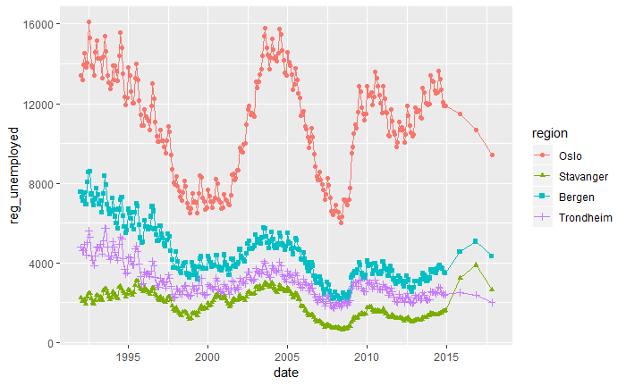

```r
ggplot(subset(df_10594, sex == "Both sexes"), aes(x = date, y = reg_unemployed, colour = region)) + geom_point(aes(shape = region)) + geom_line()
```

### 07459 Population by region, age and gender

```r
skim(df_07459)
```

```
Skim summary statistics
 n obs: 27984
 n variables: 6

-- Variable type:factor --------------------------------------------------------
 variable missing complete     n n_unique                                 top_counts ordered
      age       0    27984 27984      106     0 y: 264, 1 y: 264, 2 y: 264, 3 y: 264   FALSE
 contents       0    27984 27984        1                          Per: 27984, NA: 0   FALSE
   region       0    27984 27984        4 Osl: 6996, Sta: 6996, Ber: 6996, Tro: 6996   FALSE
      sex       0    27984 27984        2              Mal: 13992, Fem: 13992, NA: 0   FALSE
     year       0    27984 27984       33     198: 848, 198: 848, 198: 848, 198: 848   FALSE

-- Variable type:integer -------------------------------------------------------
 variable missing complete     n    mean      sd p0 p25 p50  p75 p100     hist
    value       0    27984 27984 1222.16 1221.38  0 395 917 1590 8186 ▇▃▁▁▁▁▁▁
```

```r
unique(df_07459$region)
```

```
[1] Oslo municipality Stavanger         Bergen            Trondheim (-2017)
Levels: Oslo municipality Stavanger Bergen Trondheim (-2017)
```

Allright, at least there were no missing values this time. There are six variables: age, contents, region, sex, year and value. We want to drop the contents variable, rename two of the regions and rename and recode year as a date format.

```r
df_07459 <- df_07459 %>%
        mutate( date = lubridate::parse_date_time(year, "y"),
                region = fct_recode(region,
                                    Oslo = "Oslo municipality",
                                    Trondheim = "Trondheim (-2017)"),
                value = as.numeric(value)) %>%
        rename( population_size = value) %>%
        select(-c(year, contents)) %>%
        filter(date >= as.Date("1992-01-01") & date < as.Date("2018-01-01"))
saveRDS(df_07459, file = here("data/processed", "df_population.rds"))
```

Let’s take a look:

```r
skim(df_07459)
```

```
Skim summary statistics
 n obs: 22048
 n variables: 5

-- Variable type:factor --------------------------------------------------------
 variable missing complete     n n_unique                                 top_counts ordered
      age       0    22048 22048      106     0 y: 208, 1 y: 208, 2 y: 208, 3 y: 208   FALSE
   region       0    22048 22048        4 Osl: 5512, Sta: 5512, Ber: 5512, Tro: 5512   FALSE
      sex       0    22048 22048        2              Mal: 11024, Fem: 11024, NA: 0   FALSE

-- Variable type:numeric -------------------------------------------------------
        variable missing complete     n    mean      sd p0 p25 p50  p75 p100     hist
 population_size       0    22048 22048 1257.48 1248.12  0 415 943 1604 7954 ▇▅▁▁▁▁▁▁

-- Variable type:POSIXct -------------------------------------------------------
 variable missing complete     n        min        max     median n_unique
     date       0    22048 22048 1992-01-01 2017-01-01 2004-07-02       26
```

### 06726 housing prices by number and total value by region

```r
skim(df_06726) #Show nice summary stats
```

```
Skim summary statistics
 n obs: 260
 n variables: 4

-- Variable type:factor --------------------------------------------------------
 variable missing complete   n n_unique                         top_counts ordered
 contents       0      260 260        2          Tra: 130, Tot: 130, NA: 0   FALSE
   region       0      260 260        5 The: 52, Osl: 52, Sta: 52, Ber: 52   FALSE
     year       0      260 260       26 199: 10, 199: 10, 199: 10, 199: 10   FALSE

-- Variable type:integer -------------------------------------------------------
 variable missing complete   n       mean          sd   p0     p25    p50         p75      p100     hist
    value       0      260 260 18995312.9 51542040.72 1008 4012.75 357180 10544921.25 315634243 ▇▁▁▁▁▁▁▁
```

```r
df_06726[is.na(df_06726$value),] #To locate and show the missing values
```

| region | contents | year | value |
| --- | --- | --- | --- |

```r
unique(df_06726$region) #To show all the regions
```

```
[1] The whole country Oslo municipality Stavanger         Bergen            Trondheim (-2017)
Levels: The whole country Oslo municipality Stavanger Bergen Trondheim (-2017)
```

Which again reminds us of previous data. Let us rename the value-variable, rename and recode the year as date, reanme the regions. On top of that we want to create an average housing values by dividing the total value of transfers by the transfer volume.

```r
df_06726 <- df_06726 %>%
        spread( key = contents, value = value)  %>%
        rename( home_transfers = "Transfers (number)", trans_val_in_1000 = "Total purchase prise (1 000 NOK)") %>%
        mutate( home_transfers = as.numeric(home_transfers),
                trans_val_in_1000 = as.numeric(trans_val_in_1000),
                ave_home_price = (trans_val_in_1000 / home_transfers)*1000,
                date = lubridate::parse_date_time(year, "y"),
                region = fct_recode(region,
                                    Oslo = "Oslo municipality",
                                    Trondheim = "Trondheim (-2017)")) %>%
        select(-c(year))
saveRDS(df_06726, file = here("data/processed", "df_home_values.rds"))
```

Let’s take a look:

```r
skim(df_06726)
```

```
Skim summary statistics
 n obs: 130
 n variables: 5

-- Variable type:factor --------------------------------------------------------
 variable missing complete   n n_unique                         top_counts ordered
   region       0      130 130        5 The: 26, Osl: 26, Sta: 26, Ber: 26   FALSE

-- Variable type:numeric -------------------------------------------------------
          variable missing complete   n        mean          sd        p0        p25         p50         p75         p100     hist
    ave_home_price       0      130 130  2289858.33  1306628.13 568785.48 1134704.82  2141310.47  3269264.07   6597681.56 ▇▆▅▃▃▁▁▁
    home_transfers       0      130 130    16897.75    26324.92   1008       2565        3992.5     10418.75     88652    ▇▁▁▁▁▁▁▁
 trans_val_in_1000       0      130 130 37973728.04 67880867.82 625708    4058391.75 10599705.5  33778940.5  315634243    ▇▁▁▁▁▁▁▁

-- Variable type:POSIXct -------------------------------------------------------
 variable missing complete   n        min        max     median n_unique
     date       0      130 130 1992-01-01 2017-01-01 2004-07-02       26
```

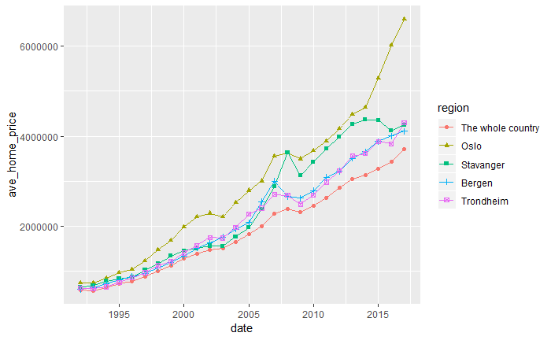

```r
ggplot (df_06726, aes(x = date, y = ave_home_price, colour = region )) + geom_line() + geom_point(aes(shape=region))
```

### The Europe Brent Spot Price

```r
skim(df_europe_brent_spot)
```

```
Skim summary statistics
 n obs: 381
 n variables: 2

-- Variable type:numeric -------------------------------------------------------
 variable missing complete   n mean    sd   p0   p25  p50   p75   p100     hist
    price       0      381 381   46 33.01 9.82 18.67 30.2 67.49 132.72 ▇▃▂▂▂▁▂▁

-- Variable type:POSIXct -------------------------------------------------------
 variable missing complete   n        min        max     median n_unique
     date       0      381 381 1987-05-15 2019-01-15 2003-03-15      381
```

And then some filtering

```r
df_europe_brent_spot <- df_europe_brent_spot %>%
        filter(date >= as.Date("1992-01-01") & date < as.Date("2018-01-01"))
saveRDS(df_europe_brent_spot, file = here("data/processed", "df_brent_oil_price.rds"))
```

And we are good to go. Let’s take a look:

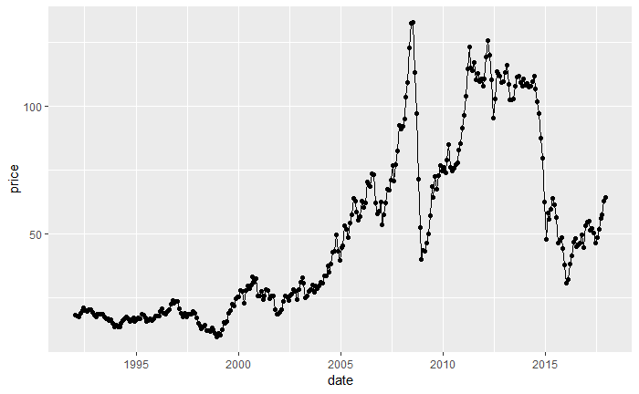

```r
ggplot (df_europe_brent_spot, aes(x = date, y = price)) + geom_line() + geom_point()
```

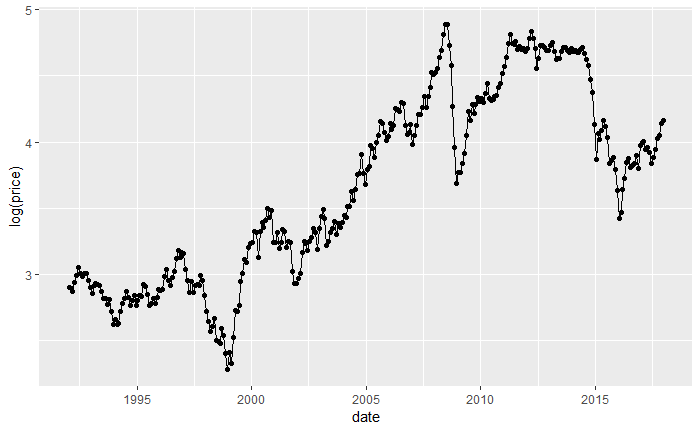

```r
ggplot (df_europe_brent_spot, aes(x = date, y = log(price))) + geom_line() + geom_point()
```

# If we want the data as a single data frame

```r
df_unemployment <- readRDS(here("data/processed", "df_unemployment.rds"))
df_population <- readRDS(here("data/processed", "df_population.rds"))
df_home_values <- readRDS(here("data/processed", "df_home_values.rds"))
df_brent_oil_price <- readRDS(here("data/processed", "df_brent_oil_price.rds"))
```

```r
x <- data_frame(i = c("a","b","c"), j = 1:3)
```

```
`data_frame()` is deprecated, use `tibble()`.
```